# Healthcare Cost Analysis

Swapnil Narwade

6/4/2021

### **Background and Objective:**

A nationwide survey of hospital costs conducted by the US Agency for Healthcare consists of hospital records of inpatient samples. The given data is restricted to the city of Wisconsin and relates to patients in the age group 0-17 years. The agency wants to analyze the data to research on healthcare costs and their utilization.

#### **Analysis to be done:**

1. To record the patient statistics, the agency wants to find the age category of people who frequently visit the hospital and has the maximum expenditure.
2. In order of severity of the diagnosis and treatments and to find out the expensive treatments, the agency wants to find the diagnosis-related group that has maximum hospitalization and expenditure.
3. To make sure that there is no malpractice, the agency needs to analyze if the race of the patient is related to the hospitalization costs.
4. To properly utilize the costs, the agency has to analyze the severity of the hospital costs by age and gender for the proper allocation of resources.
5. Since the length of stay is the crucial factor for inpatients, the agency wants to find if the length of stay can be predicted from age, gender, and race.
6. To perform a complete analysis, the agency wants to find the variable that mainly affects hospital costs.

```r
# Load the Hospital dataset :
hosp_data <- read.csv('HospitalCosts.csv')
head(hosp_data)
```

```
##   AGE FEMALE LOS RACE TOTCHG APRDRG
## 1  17      1   2    1   2660    560
## 2  17      0   2    1   1689    753
## 3  17      1   7    1  20060    930
## 4  17      1   1    1    736    758
## 5  17      1   1    1   1194    754
## 6  17      0   0    1   3305    347
```

##### **1.To record the patient statistics, the agency wants to find the age category of people who frequently visit the hospital and has the maximum expenditure.**

```r
# Treating missing values first.
colSums(is.na(hosp_data))
```

```
##    AGE FEMALE    LOS   RACE TOTCHG APRDRG
##      0      0      0      1      0      0
```

```r
hosp_data <- na.omit(hosp_data)
colSums(is.na(hosp_data))
```

```
##    AGE FEMALE    LOS   RACE TOTCHG APRDRG
##      0      0      0      0      0      0
```

```r
# patient statistics : Age group who frequently visits hospital
summary(as.factor(hosp_data$AGE))
```

```
##   0   1   2   3   4   5   6   7   8   9  10  11  12  13  14  15  16  17
## 306  10   1   3   2   2   2   3   2   2   4   8  15  18  25  29  29  38
```

```r
max(table(hosp_data$AGE))
```

```
## [1] 306
```

```r
which.max(table(hosp_data$AGE))
```

```
## 0
## 1
```

- We can say age group 0 to 1 visits the hospital most.

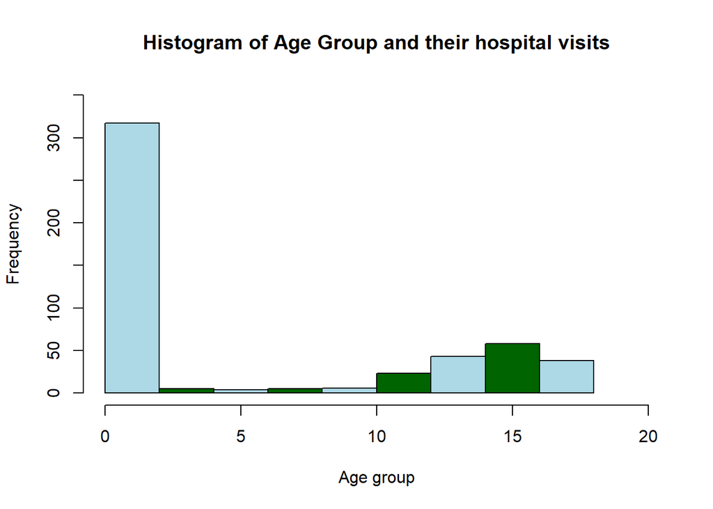

```r
# Histogram of Age group to understand frequency of particular age group visiting hospital :
hist(hosp_data$AGE, main = 'Histogram of Age Group and their hospital visits',
     xlab = 'Age group', border = 'black', col = c('light blue', 'dark green'), xlim = c(0,20), ylim = c(0,350))
```

```r
# Summarizing total expenditure based on age group :
ExpBasedAge <- aggregate(TOTCHG ~ AGE, data = hosp_data, sum)
print(paste('Total Expenditure =', max(ExpBasedAge)))
```

```
## [1] "Total Expenditure = 676962"
```

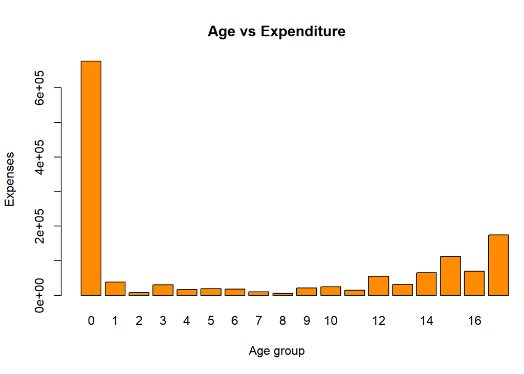

```r
# Visualization : Age vs Expenditure
barplot(tapply(ExpBasedAge$TOTCHG, ExpBasedAge$AGE, FUN = sum), main = 'Age vs Expenditure',
        xlab='Age group', ylab = 'Expenses', border='black', col = 'darkorange', xlim = c(0,20))
```

```r
summary(as.factor(hosp_data$APRDRG))
```

```
##  21  23  49  50  51  53  54  57  58  92  97 114 115 137 138 139 141 143 204 206
##   1   1   1   1   1  10   1   2   1   1   1   1   2   1   4   5   1   1   1   1
## 225 249 254 308 313 317 344 347 420 421 422 560 561 566 580 581 602 614 626 633
##   2   6   1   1   1   1   2   3   2   1   3   2   1   1   1   3   1   3   6   4
## 634 636 639 640 710 720 723 740 750 751 753 754 755 756 758 760 776 811 812 863
##   2   3   4 266   1   1   2   1   1  14  36  37  13   2  20   2   1   2   3   1
## 911 930 952
##   1   2   1
```

```r
DiagnosisCost <- aggregate(TOTCHG ~ APRDRG, data = hosp_data, FUN = sum)
DiagnosisCost[which.max(DiagnosisCost$TOTCHG),]
```

```
##    APRDRG TOTCHG
## 44    640 436822
```

##### **3. To make sure that there is no malpractice, the agency needs to analyze if the race of the patient is related to the hospitalization costs**

```r
summary(as.factor(hosp_data$RACE))
```

```
##   1   2   3   4   5   6
## 484   6   1   3   3   2
```

```r
raceInfluence <- lm(hosp_data$TOTCHG ~ hosp_data$RACE)
summary(raceInfluence)
```

```
##
## Call:
## lm(formula = hosp_data$TOTCHG ~ hosp_data$RACE)
##
## Residuals:
##    Min     1Q Median     3Q    Max
##  -2256  -1560  -1227   -258  45600
##
## Coefficients:
##                Estimate Std. Error t value Pr(>|t|)
## (Intercept)      2925.7      405.0   7.224 1.92e-12 ***
## hosp_data$RACE   -137.3      339.1  -0.405    0.686
## ---
## Signif. codes:  0 '***' 0.001 '**' 0.01 '*' 0.05 '.' 0.1 ' ' 1
##
## Residual standard error: 3895 on 497 degrees of freedom
## Multiple R-squared:  0.0003299,  Adjusted R-squared:  -0.001681
## F-statistic: 0.164 on 1 and 497 DF,  p-value: 0.6856
```

- **Here p-value is 0.69 it is much higher than 0.5**
- **We can say that race doesn’t affect the hospitalization costs.**
- **Hence there is no malpractice in the hospital.**

##### **4.To properly utilize the costs, the agency has to analyze the severity of the hospital costs by age and gender for the proper allocation of resources.**

```r
table(hosp_data$FEMALE)
```

```
##
##   0   1
## 244 255
```

```r
a <- aov(TOTCHG ~ AGE + FEMALE, data = hosp_data)
summary(a)
```

```
##              Df    Sum Sq   Mean Sq F value  Pr(>F)
## AGE           1 1.297e+08 129749266   8.759 0.00323 **
## FEMALE        1 6.522e+07  65219972   4.403 0.03638 *
## Residuals   496 7.347e+09  14812787
## ---
## Signif. codes:  0 '***' 0.001 '**' 0.01 '*' 0.05 '.' 0.1 ' ' 1
```

```r
b <- lm(TOTCHG ~ AGE + FEMALE, data = hosp_data)
summary(b)
```

```
##
## Call:
## lm(formula = TOTCHG ~ AGE + FEMALE, data = hosp_data)
##
## Residuals:
##    Min     1Q Median     3Q    Max
##  -3403  -1444   -873   -156  44950
##
## Coefficients:
##             Estimate Std. Error t value Pr(>|t|)
## (Intercept)  2719.45     261.42  10.403  < 2e-16 ***
## AGE            86.04      25.53   3.371 0.000808 ***
## FEMALE       -744.21     354.67  -2.098 0.036382 *
## ---
## Signif. codes:  0 '***' 0.001 '**' 0.01 '*' 0.05 '.' 0.1 ' ' 1
##
## Residual standard error: 3849 on 496 degrees of freedom
## Multiple R-squared:  0.02585,    Adjusted R-squared:  0.02192
## F-statistic: 6.581 on 2 and 496 DF,  p-value: 0.001511
```

- **Since the p-values of Age is much lesser than 0.05, it means Age has the most statistical significance.**
- **Similarly, gender is also less than 0.05.**
- **Hence, we can conclude that the model is statistically significant.**

##### **5. Since the length of stay is the crucial factor for inpatients, the agency wants to find if the length of stay can be predicted from age, gender, and race.**

```r
table(hosp_data$LOS)
```

```
##
##   0   1   2   3   4   5   6   7   8   9  10  12  15  17  18  23  24  39  41
##  15  79 223  98  38  14   8  11   1   1   1   2   1   1   2   1   1   1   1
```

```r
stay <- aov(LOS ~ AGE + FEMALE + RACE, data = hosp_data)
summary(stay)
```

```
##              Df Sum Sq Mean Sq F value Pr(>F)
## AGE           1     27  26.907   2.378  0.124
## FEMALE        1     17  16.510   1.459  0.228
## RACE          1      1   1.165   0.103  0.748
## Residuals   495   5600  11.313
```

```r
stay <- lm(LOS ~ AGE + FEMALE + RACE, data = hosp_data)
summary(stay)
```

```
##
## Call:
## lm(formula = LOS ~ AGE + FEMALE + RACE, data = hosp_data)
##
## Residuals:
##    Min     1Q Median     3Q    Max
##  -3.22  -1.22  -0.85   0.15  37.78
##
## Coefficients:
##             Estimate Std. Error t value Pr(>|t|)
## (Intercept)  2.94377    0.39318   7.487 3.25e-13 ***
## AGE         -0.03960    0.02231  -1.775   0.0766 .
## FEMALE       0.37011    0.31024   1.193   0.2334
## RACE        -0.09408    0.29312  -0.321   0.7484
## ---
## Signif. codes:  0 '***' 0.001 '**' 0.01 '*' 0.05 '.' 0.1 ' ' 1
##
## Residual standard error: 3.363 on 495 degrees of freedom
## Multiple R-squared:  0.007898,   Adjusted R-squared:  0.001886
## F-statistic: 1.314 on 3 and 495 DF,  p-value: 0.2692
```

- **The p-value is higher than 0.05 for age, gender and race, indicating there is no linear relationship between these variables and length of stay.**
- **Hence, age, gender and race cannot be used to predict the length of stay of inpatients.**

##### **6.To perform a complete analysis, the agency wants to find the variable that mainly affects hospital costs.**

```r
compAnalysis <- aov(TOTCHG ~., data = hosp_data)
summary(compAnalysis)
```

```
##              Df    Sum Sq   Mean Sq F value   Pr(>F)
## AGE           1 1.297e+08 1.297e+08  18.998 1.59e-05 ***
## FEMALE        1 6.522e+07 6.522e+07   9.550  0.00211 **
## LOS           1 3.086e+09 3.086e+09 451.889  < 2e-16 ***
## RACE          1 1.715e+06 1.715e+06   0.251  0.61652
## APRDRG        1 8.923e+08 8.923e+08 130.648  < 2e-16 ***
## Residuals   493 3.367e+09 6.830e+06
## ---
## Signif. codes:  0 '***' 0.001 '**' 0.01 '*' 0.05 '.' 0.1 ' ' 1
```

```r
compAnalysis <- lm(TOTCHG ~., data = hosp_data)
summary(compAnalysis)
```

```
##
## Call:
## lm(formula = TOTCHG ~ ., data = hosp_data)
##
## Residuals:
##    Min     1Q Median     3Q    Max
##  -6377   -700   -174    122  43378
##
## Coefficients:
##              Estimate Std. Error t value Pr(>|t|)
## (Intercept) 5218.6769   507.6475  10.280  < 2e-16 ***
## AGE          134.6949    17.4711   7.710 7.02e-14 ***
## FEMALE      -390.6924   247.7390  -1.577    0.115
## LOS          743.1521    34.9225  21.280  < 2e-16 ***
## RACE        -212.4291   227.9326  -0.932    0.352
## APRDRG        -7.7909     0.6816 -11.430  < 2e-16 ***
## ---
## Signif. codes:  0 '***' 0.001 '**' 0.01 '*' 0.05 '.' 0.1 ' ' 1
##
## Residual standard error: 2613 on 493 degrees of freedom
## Multiple R-squared:  0.5536, Adjusted R-squared:  0.5491
## F-statistic: 122.3 on 5 and 493 DF,  p-value: < 2.2e-16
```

- **We can say that Age, Length of stay (LOS) and patient refined diagnosis related groups(APRDRG) have low p-value and three stars next to it. So they are the ones with statistical significance.**
- **These three variables mainly effects the hospital cost.**